# Team1-PriorityUseCause-Final.Rmd

Madeleine Thompson, Amadi Afua Sefah-Twerefour, Paul Ernst, Maggie Gaspar

4/12/2022

# The Relationship between Priority, Use, and Cause in Impaired South Carolina Waters between 2016 and 2018

### By Madeleine Thompson, Amadi Afua Sefah-Twerefour, Paul Ernst, & Maggie Gaspar

### 1. Introduction.

The South Carolina Department of Health and Environmental Control (SCDHEC, or DHEC) publishes a list of impaired waters every 2 years as per the Federal Clean Water Act (Marcus, 2020). These are determined by a combination of state and federal standards, with data obtained from a wide variety of sources, including beach monitoring stations, water quality assessments, and surveys of populations of bacteria, macroinvertebrates, and so forth. Of these waters that are considered impaired, or harmed in their intended use by some cause, each is assigned a Priority Rank from 1 to 3, with 1 being the highest priority and 3 being the lowest. The highest priority waters are intended to be addressed the soonest, with lower-priority waters taking longer to be fully addressed. Since these priority ranks are not empirically determined, it is necessary to analyze them in order to ensure that the arbitrary nature of their selection has not failed to address certain geographical areas, causes of impairment, or uses of water bodies.

In this study, we use the latest impaired water body assessments for 2016 and 2018 and divide them by location, priority rank, use, and cause in order to determine where the SCDHEC is focusing its resources and where it might allocate them better in the future.

### 2. Results & Discussion.

#### 2.1. Impaired Waters, Basins, and Priority Ranks.

To begin our investigation, we map the water bodies of South Carolina by whether or not they are impaired (Figure 1).

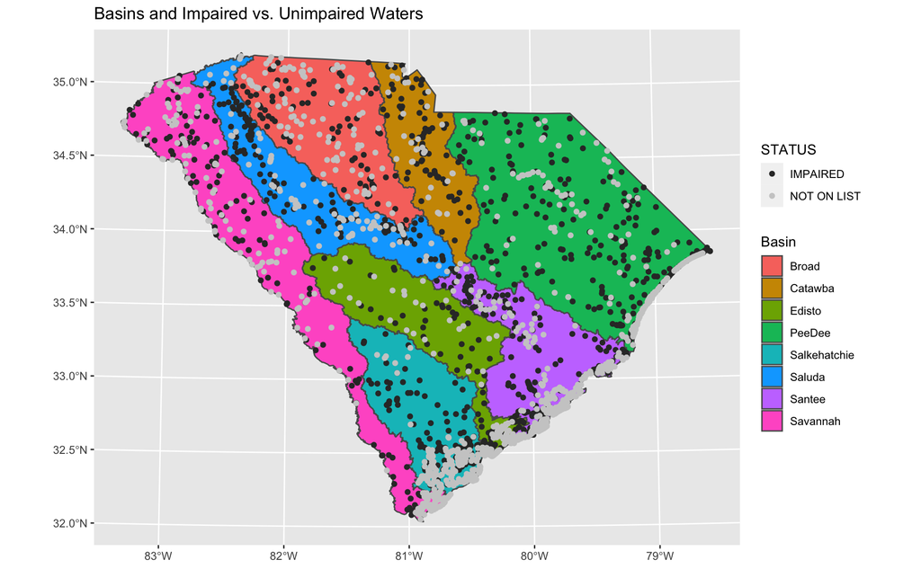

**Figure 1:** *Waters listed in the impaired data versus not listed as impaired per each basin in South Carolina.*

We find that the vast majority of coastal waters are not impaired, while midstate waters tend to be more impaired than not. The Catawba and PeeDee basins are particularly noteworthy for a high ratio of impaired to unimpaired interior waters.

Of the waters that are on this list, we plot their priority rank in 2018 (Figure 2) and 2016 (Figure 3).

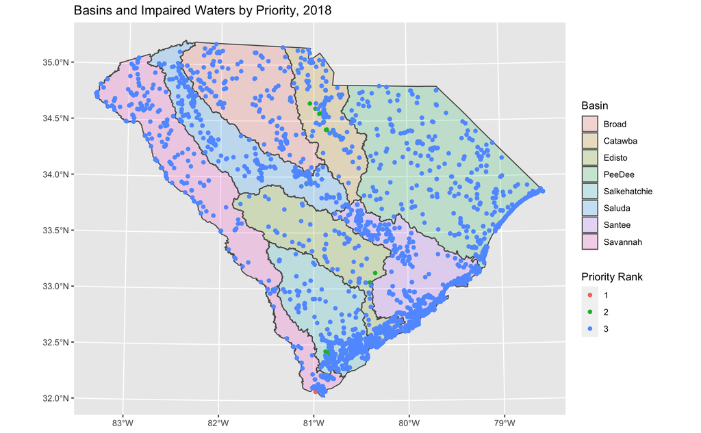

**Figure 2:** *Priority Rank of waters listed in the impaired data per each basin in South Carolina, 2018.*

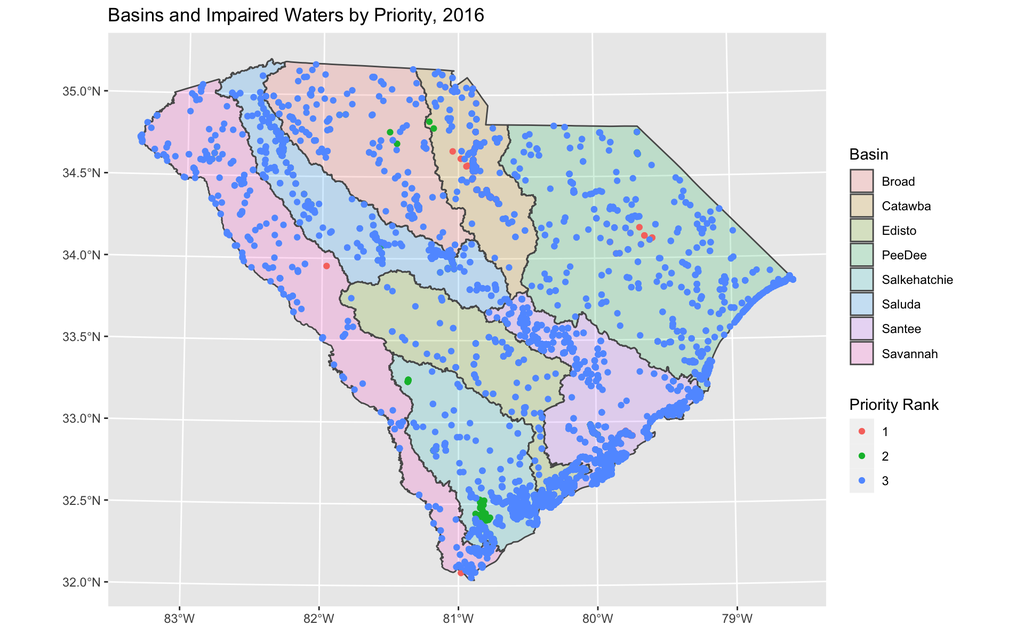

**Figure 3:** *Priority Rank of waters listed in the impaired data per each basin in South Carolina, 2016. The original priority rank at the beginning of the study period is assigned to water bodies with multiple ranks over time from multiple measurement.*

#### 2.2. Cause, Use, and Priority Rank in Impaired Waters.

We examine the relationship between Priority Rank and Use in Figure 4.

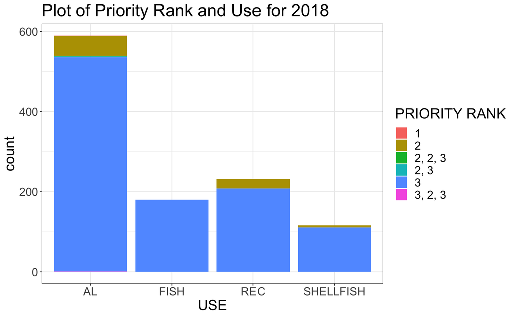

**Figure 4:** *Use of different impaired waters, colored by Priority Rank, 2018. Multiple ranks indicate a sequence of rankings over time from multiple readings over the study period.*

About half of all waters are used for AL, or Aquatic Life, listed in the 2018 report submitted by the state of South Carolina to the EPA as waters whose goal is to propagate a “balanced indigenous aquatic community of fauna and flora.” The rest of the major uses listed are for fishing, shellfishing, and recreation. We note that no fishing-use-related waters are impaired beyond rank 3, and that the highest absolute number of water bodies that are impaired are used for aquatic life. That stated, the relative fractions for impaired waters at rank 2 are comparable between aquatic life and recreation, with a smaller proportion in shellfish usage.

We continue by examining the priority rank as related to the cause of this priority rank (Figure 5).

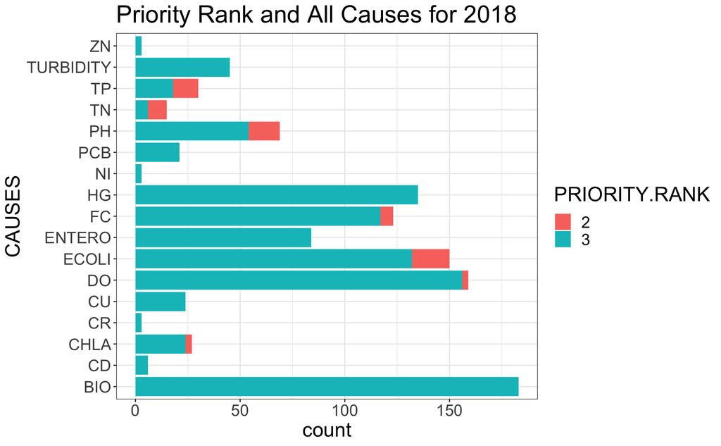

```
##
##  Kruskal-Wallis rank sum test
##
## data:  imp_2018_use_no_multipleranks$CAUSE.S. by imp_2018_use_no_multipleranks$PRIORITY.RANK
## Kruskal-Wallis chi-squared = 11.871, df = 1, p-value = 0.0005702
```

**Figure 5:** *Cause of different impaired waters, colored by Priority Rank, 2018.*

We find that the overwhelming cause of impaired waters as a whole is due to adverse macroinvertebrate activity (BIO) and bacteria (E-coli/enterococci/Fecal Coliform, ECOLI/ENTERO/FC). Following behind direct biological impairment is dissolved oxygen (DO) and mercury (HG) with a smaller set of waters impaired by pH imbalances and turbidity concerns. In proportion to the total number of waters impaired, the most waters heavily impaired (priority rank 2) belongs to total phosphorus (TP) and total nitrogen (TN). To summarize, in 2018, the most waters are biologically impaired, with metal contamination, nutrients, and turbidity all secondary. We use a Kruskal-Wallis rank sum test to determine if the groups (priority ranks 2 and 3) are significantly different. With 1 degree of freedom and a chi-squared value of 11.871, we arrive at a p-value of 0.0005702, which means that we reject the null hypothesis. In this case, our alternative hypothesis/conclusion is that the two ranks are significantly different between the causes that we see above, which matches our analysis.

Finally for 2018, we examine the relationship between use and cause (Figure 6).

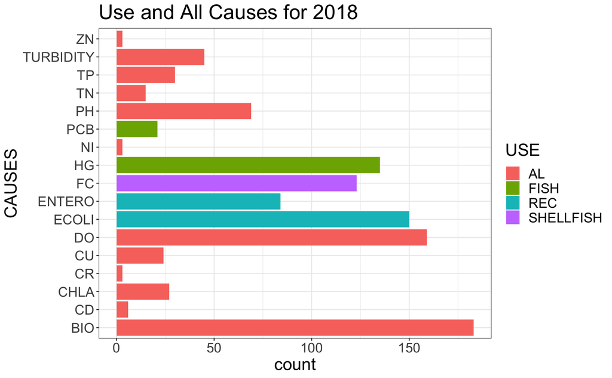

```
##
##  Kruskal-Wallis rank sum test
##
## data:  imp_2018_use_no_multipleranks$CAUSE.S. by imp_2018_use_no_multipleranks$USE
## Kruskal-Wallis chi-squared = 81.413, df = 3, p-value < 2.2e-16
```

**Figure 6:** *Cause of different impaired waters, colored by use, 2018.*

The causes and uses of impaired waters are heavily related. As PCBs (Polychlorinated Biphenyls) and mercury impairment are naturally measured through fish catch, these categories will be prevalent for fish catching usages. A similar conclusion can be reached for FC and shellfish, as well as E-coli/enterococci and recreational use. All other categories of cause are classified as aquatic life (mixed). From this figure we can observe why AL and REC are categories with such impaired waters– bacterial, turbidity, and nutrient causes are all filed under these. Also unsurprisingly, our Kruskal-Wallis rank sum test returns a significant value for this set, a given that the uses and causes do not mix.

We compare the results in the above Figures 4, 5, and 6 with similar results for 2016, beginning with the relationship between priority rank and use (Figure 7).

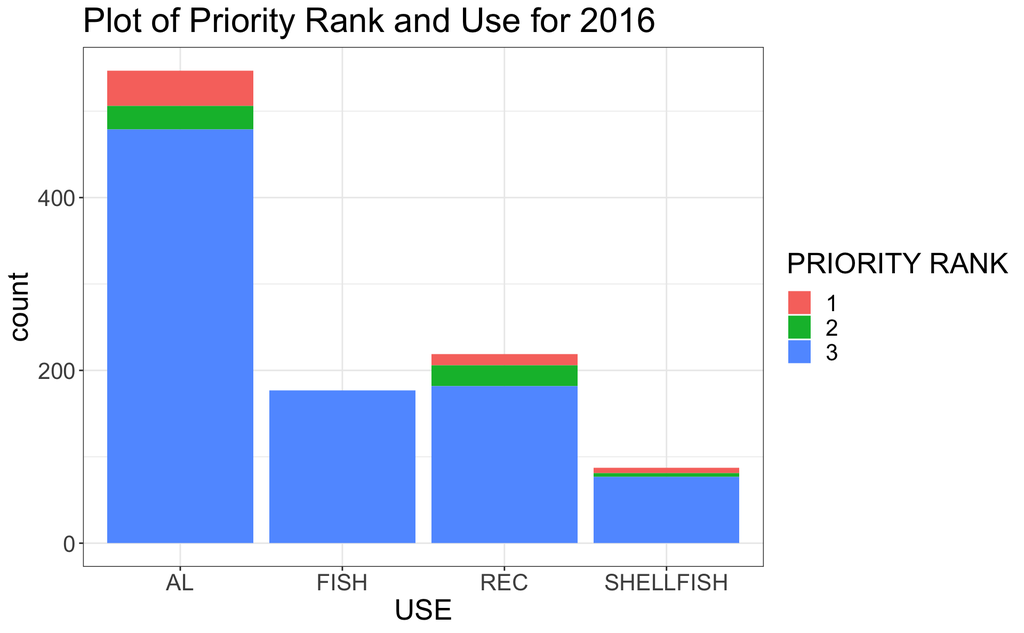

**Figure 7:** *Use of different impaired waters, colored by Priority Rank, 2016.*

Much the same conclusions can be drawn from Figure 7 as from Figure 4, as AL and REC dominate the impaired waters by both total number and number of heavily impaired waters. The only major difference is in the splitting of the large section of priority rank 2 waters in 2018 into rank 1 and rank 2 waters in 2016. In this manner, AL has more rank 1 waters than rank 2 waters, while the inverse is true for REC. Additionally, it must be noted that a larger total of waters were impaired in 2018 than 2016. We investigate further via causes (Figure 8).

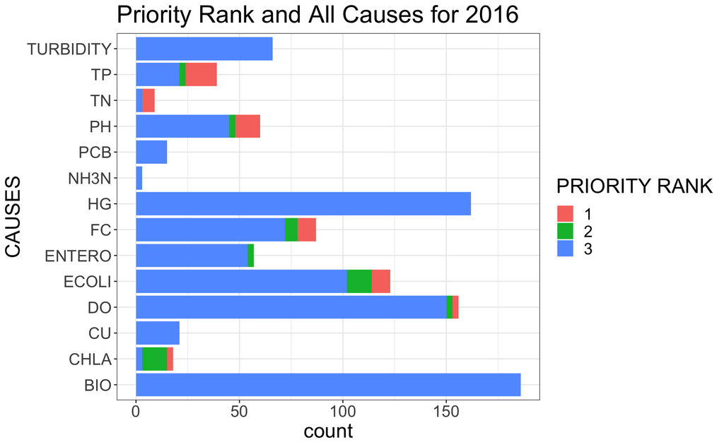

```
##
##  Kruskal-Wallis rank sum test
##
## data:  imp_2016_use_no_multipleranks$`CAUSE(S)` by imp_2016_use_no_multipleranks$`PRIORITY RANK`
## Kruskal-Wallis chi-squared = 11.068, df = 2, p-value = 0.003951
```

Lastly, we repeat the analysis of Figure 6 for 2016 (Figure 9).

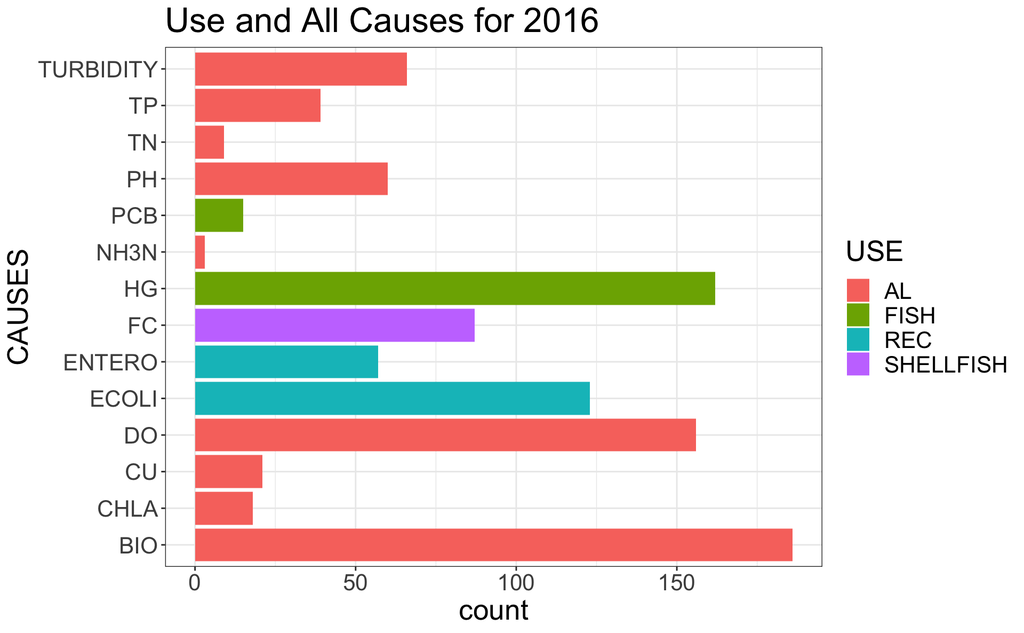

```
##
##  Kruskal-Wallis rank sum test
##
## data:  imp_2016_use_no_multipleranks$`CAUSE(S)` by imp_2016_use_no_multipleranks$USE
## Kruskal-Wallis chi-squared = 58.951, df = 3, p-value = 9.846e-13
```

**Figure 9:** *Cause of different impaired waters, colored by use, 2016.*

Our findings here are similar to those in Figure 6 and explain the increases and proportions seen in Figure 7. Fundamentally, AL increases due to nutrient impairment, while REC increases due to bacteria. As expected from our previous results, these distributions are significantly different (Kruskal-Wallis Test).

### 4. Works Cited.

Marcus, Mike (2020). *The State of South Carolina’s 2018 Integrated Report (IR)*. Retrieved 22 April 2022.